# ggplot 101

In this notebook, we’ll get some practice making plots with ggplot using the [Palmer Penguins](https://allisonhorst.github.io/palmerpenguins/) dataset.

# Setup

Load packages and set conflicted preferences:

```r
library(dplyr)
library(ggplot2)

## Load the conflicted package
library(conflicted)
conflict_prefer("filter", "dplyr", quiet = TRUE)
conflict_prefer("count", "dplyr", quiet = TRUE)
conflict_prefer("select", "dplyr", quiet = TRUE)
conflict_prefer("arrange", "dplyr", quiet = TRUE)
```

Next, we load the Palmer Penguins data frame:

```r
library(palmerpenguins)
glimpse(penguins)
```

```
Rows: 344
Columns: 8
$ species           <fct> Adelie, Adelie, Adelie, Adelie, Adelie, Adelie, Adelie, Adelie, Adelie, Adelie, Adelie,…
$ island            <fct> Torgersen, Torgersen, Torgersen, Torgersen, Torgersen, Torgersen, Torgersen, Torgersen,…
$ bill_length_mm    <dbl> 39.1, 39.5, 40.3, NA, 36.7, 39.3, 38.9, 39.2, 34.1, 42.0, 37.8, 37.8, 41.1, 38.6, 34.6,…
$ bill_depth_mm     <dbl> 18.7, 17.4, 18.0, NA, 19.3, 20.6, 17.8, 19.6, 18.1, 20.2, 17.1, 17.3, 17.6, 21.2, 21.1,…
$ flipper_length_mm <int> 181, 186, 195, NA, 193, 190, 181, 195, 193, 190, 186, 180, 182, 191, 198, 185, 195, 197…
$ body_mass_g       <int> 3750, 3800, 3250, NA, 3450, 3650, 3625, 4675, 3475, 4250, 3300, 3700, 3200, 3800, 4400,…
$ sex               <fct> male, female, female, NA, female, male, female, male, NA, NA, NA, NA, female, male, mal…
$ year              <int> 2007, 2007, 2007, 2007, 2007, 2007, 2007, 2007, 2007, 2007, 2007, 2007, 2007, 2007, 200…
```

# Scatterplots

Our first ggplot will be a simple scatterplot of bill length and flipper length:

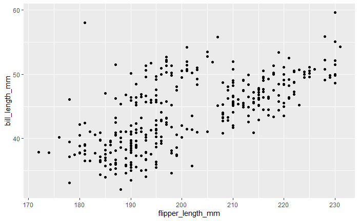

```r
ggplot(data = penguins,
       mapping = aes(x = flipper_length_mm, y = bill_length_mm)) +
  geom_point()
```

Next, change the color of the dots by manually specifying a color value in the geom function:

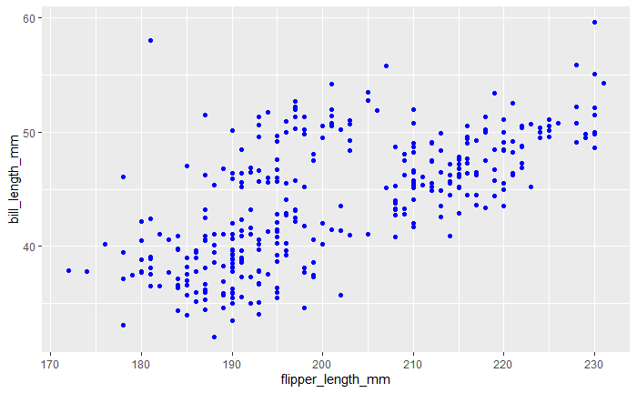

```r
ggplot(data = penguins,
       mapping = aes(x = flipper_length_mm, y = bill_length_mm)) +
  geom_point(color = "blue")
```

Next, we color them by species:

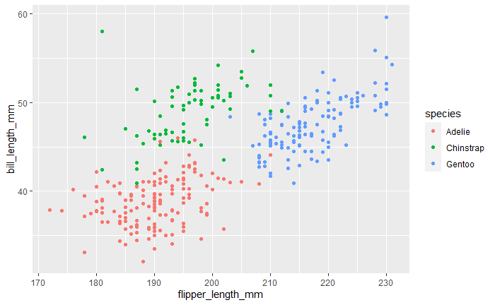

```r
ggplot(data = penguins,
       mapping = aes(x = flipper_length_mm, y = bill_length_mm, color = species)) +
  geom_point()
```

Don’t like the default colors (which are not color-blind friendly)? We can specify our preferred palette by tacking on `scale_color_manual()` to our expression:

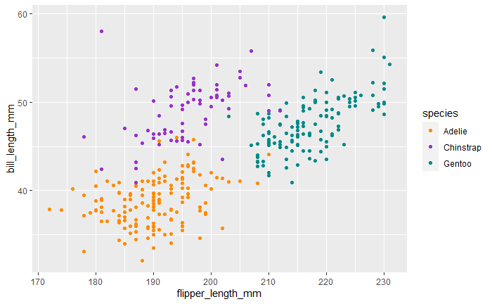

```r
ggplot(data = penguins,
       mapping = aes(x = flipper_length_mm, y = bill_length_mm, color = species)) +
  geom_point() +
  scale_color_manual(values = c("darkorange","darkorchid","cyan4"))
```

# CHALLENGE 1

1A) Make a scatterplot with *bill depth* on the x-axis and *body mass* on the y-axis. [[Answer](https://bit.ly/3bKiYtB)]

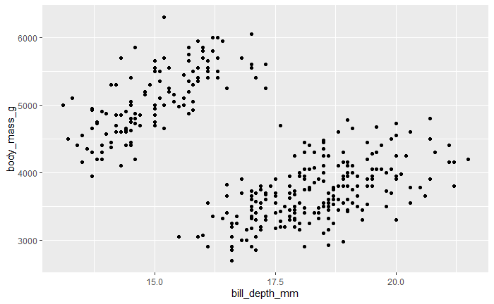

```r
ggplot(data = penguins,
       mapping = aes(x = bill_depth_mm, y = body_mass_g)) +
  geom_point()
```

1B) Visualize your plot of *bill depth* vs. *body mass* by species, using different i) colors, and ii) shapes. [[Hint](https://bit.ly/3C00mjY)] [[Solution](https://bit.ly/3pcHeaL)]

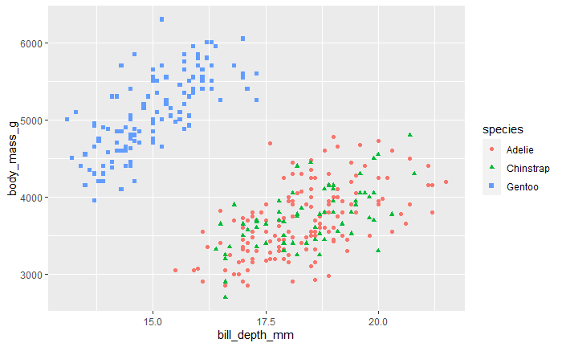

```r
ggplot(data = penguins,
       mapping = aes(x = bill_depth_mm, y = body_mass_g, color = species, shape = species)) +
  geom_point()
```

# Facets

Another way we can differentiate the points is by using *facets* (i.e., a separate plot for each group). We can ask for facets by adding `facet_wrap()` or `facet_grid()` to our plot expression:

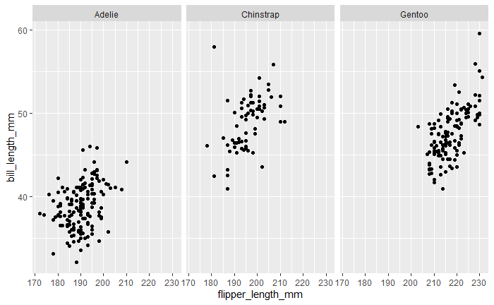

```r
ggplot(data = penguins,
       mapping = aes(x = flipper_length_mm, y = bill_length_mm)) +
  geom_point() +
  facet_wrap(~species)
```

# Boxplots

You can use `geom_boxplot()` to draw boxplots.

To create multiple boxplots for different groups of data, pass a column that has categorical (character or factor) values as either the `x` or `y` property in `aes()`. ggplot will take care of the rest!

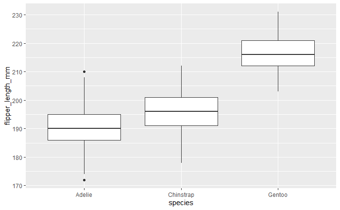

```r
ggplot(penguins, aes(x = species, y = flipper_length_mm)) +
  geom_boxplot()
```

# CHALLENGE 2

Make a histogram of flipper length for each species. [[Hint](https://bit.ly/3pfmEqm)] [[Solution](https://bit.ly/3pjcfJX)]

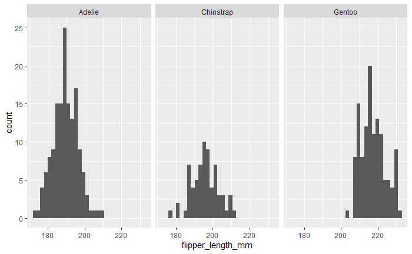

```r
ggplot(penguins, aes(x = flipper_length_mm)) +
  geom_histogram() +
  facet_wrap(~species)
```